# Machine Learning Homework 3 - Problem 11 - Ivan Aguilar

Write a program that implements the perceptron algorithm and test the running time and the probability of error of the resulting linear classifier. Consider both linearly separable and non-separable data.

For the non-separable case, generate the two class-conditional distributions as multivariate normals with means (0, . . . , 0) and (m, 0, 0, . . . , 0) and identity covariance matrix. Here the algorithm never stops making updates so run it by passing through the data set several times and define a stopping time. Again, test the performance of the classifier for several sample sizes, dimensions, and choices of m. Compare the obtained probability of error to the Bayes risk.

```python
from sklearn.linear_model import Perceptron
import pandas as pd
import numpy as np
import datetime as dt
import matplotlib.pyplot as plt
from matplotlib.pyplot import plot
import seaborn as sns
# grey background
sns.set(style="darkgrid")
```

### Auxiliary functions

```python
from IPython.display import clear_output

# Auxiliary functions

def generate_data_mult_gaussian(n, d, min, max, m):
    identitym = np.identity(d)
    meanm = [m]*1 + [0]*(d-1)
    meanz = [0]*d

    data = np.empty([n,d])
    y = np.empty([n,1])

    columns = ['x'+str(x) for x in range(1,d+1)]
    for x in range(n):
        yassign = np.random.uniform(min,max,d)
        x_avg = sum(yassign)/d
        if x_avg>np.random.uniform(min,max,1):
            data[x] = np.random.multivariate_normal(meanz,identitym,1)
            y[x]=1
        else:
            data[x] = np.random.multivariate_normal(meanm,identitym,1)
            y[x]=-1
    return data, y, columns

def generate_data(n, d, min, max, margin):
    data = np.empty([n,d])
    y = np.empty([n,1])

    columns = ['x'+str(x) for x in range(1,d+1)]
    for x in range(n):
        data[x] = np.random.uniform(min,max,d)
        x_avg = sum(data[x])/d
        if x_avg>np.random.uniform(min,max,1):
            y[x]=1
            data[x][0]=np.random.uniform(min, -margin, 1)
        else:
            y[x]=-1
            data[x][0]=np.random.uniform(margin, max, 1)
    return data, y, columns


def get_data(n, d, min, max, margin, exps, err_exps, m, sep, tol):
    s_score = 0
    s_duration = 0
    s_iterations = 0
    s_score_err = 0
    for i in range(exps):
        if sep == True:
            data_np, y, columns = generate_data(n, d, min, max, margin)
        else:
            data_np, y, columns = generate_data_mult_gaussian(n, d, min, max, m)

        data = pd.DataFrame(data_np)
        y = pd.DataFrame(y)
        data = pd.concat([data, y], axis=1)
        data.columns = columns + ['y']

        # run perceptron
        x = data.drop('y', axis=1)
        y = data['y']
        score, duration, iterations, clf = exec_perceptron(x, y, tol)
        score = clf.score(x,y)

        s_score = s_score + score
        s_duration += duration
        s_iterations += iterations

        if i == 0:
            score2, duration2, iterations2, clf2 = exec_perceptron(x, y, tol)
        score_err = clf2.score(x, y)
        s_score_err += score_err
    return data, 1-(s_score/exps), s_duration/exps, s_iterations/exps, 1-(s_score_err/exps)


def exec_perceptron(x, y, tol):
    start_time = dt.datetime.now()
    clf = Perceptron(tol=tol, random_state=0, verbose=0, max_iter=1000, n_jobs=3)
    clf.fit(x, y)
    end_time = dt.datetime.now()
    duration = (end_time - start_time).microseconds
    score = clf.score(x, y)
    iterations = clf.n_iter_
    return score, duration, iterations, clf
```

### Separable and Non-separable samples

```python
# set parameters
a = [1,0.5,0.02, 0.1]
d = range(100,501,100)
n = [50,100,500,1000]
m = [1,3,5]
exps = 50
sep = True
```

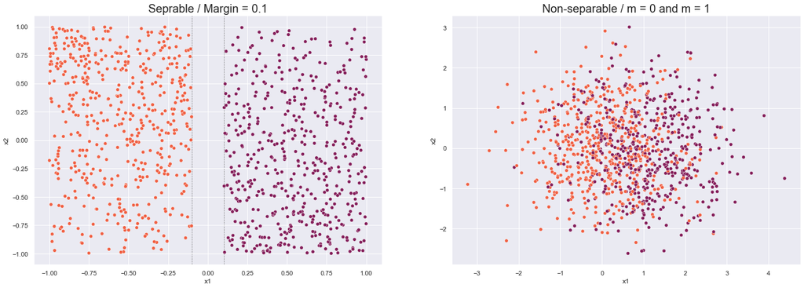

```python
import matplotlib.pyplot as plt
import seaborn as sns

palette = sns.color_palette('rocket', 2)

fig1, ax1 = plt.subplots(1, 2, figsize=(24,8))

#Separable example
data, score, duration, iterations, score_err = get_data(n[3], 2, -1, 1, a[3], exps, err_exps, m[0], True, tol=1e-3)
data_plot = pd.DataFrame(data)
ax1[0].set_title(label = 'Seprable / Margin = 0.1', size = 20)
g2 = sns.scatterplot(data=data_plot, x='x1', y='x2', hue='y', legend=False, ax=ax1[0],palette=palette)
g2.axvline(x=-a[3], ymin=0, ymax=1, c="gray", ls='--', linewidth=0.8, zorder=0, clip_on=False)
g2.axvline(x=a[3], ymin=0, ymax=1, c="gray", ls='--', linewidth=0.8, zorder=0, clip_on=False)
g2.axvline(x=0, ymin=0, ymax=1, c="gray", ls='--', linewidth=0.8, zorder=0, clip_on=False);


#Non-separable example
data, score, duration, iterations, score_err = get_data(n[3], 2, -1, 1, a[0], exps, err_exps, m[0], False, tol=1e-3)
data_plot = pd.DataFrame(data)
ax1[1].set_title(label = 'Non-separable / m = 0 and m = 1', size = 20)
g1 = sns.scatterplot(data=data_plot, x='x1', y='x2', hue='y', legend=False, ax=ax1[1],palette=palette)
```

# Separable case

For the separable case I ran the perceptron algorithm with the following parameters:

margins = [1,0.5,0.02, 0.1]

dimensions = [100, 200, 300, 400, 500]

sample_size = [50,100,500,1000]

independent draws = 50

What we can see on this case is the following:

- probability of error increases as dimensionality is increased but the amount of this increase is highly dependent on the margin and sample size, if the margin is wide, the probability of error increases at a lower rate. As the sample size increases the probability of error generally decreases (for all margins) and although still wider margins have less probability of error the differences become less significant.
- iterations are quite stable (around 10) with smaller sample size (<=100) and as the sample size increases the number of iterations start to separate depending on the margin, the narrower the margin the more iterations are required. In all cases the dimensionality change do not affect significantly the number of iterations required
- duration generally increases linearly with the increase of sample size and dimensionality, but sample size seems to be the most important increasing factor as the duration lines slope becomes very pronounced for large sample size together with a bigger separation between durations among different margins.

```python
l_score = list()
l_score_err = list()
l_duration = list()
l_iterations = list()

l_sample_size = list()
l_dimension = list()
l_margin = list()
l_m = list()

total_iter = len(a)*len(d)*len(n)
iter = 0

# loop through different options for separable case
for sample_size in n:
    for dimension in d:
        for margin in a:
            # get data
            data, score, duration, iterations, score_err = get_data(sample_size, dimension, -1, 1, margin, exps, err_exps, 0, sep, tol=1e-3)
            # accumulate lists
            l_score.append(score)
            l_score_err.append(score_err)
            l_duration.append(duration)
            l_iterations.append(iterations)

            l_sample_size.append(sample_size)
            l_dimension.append(dimension)
            l_margin.append(margin)
            iter += 1
            clear_output(wait=True)
            print(str(iter)+' out of '+str(total_iter))

results_sep = pd.DataFrame({'sample_size':l_sample_size,'dimension':l_dimension,'margin':l_margin,'error':l_score,'proba_error':l_score_err,'duration':l_duration,'iterations':l_iterations})
```

```
80 out of 80
```

### Separable case: Probablity of error

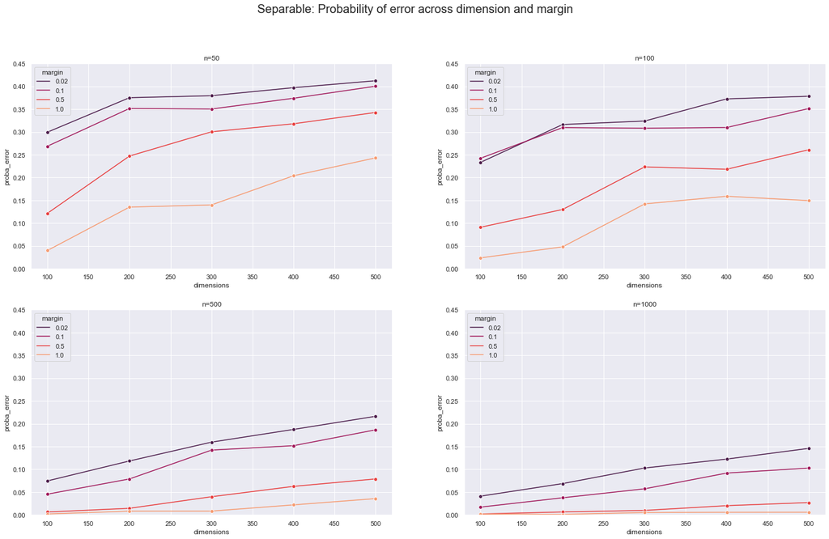

```python
fig1, ax1 = plt.subplots(2, 2, figsize=(24,14))
figure(figsize=(8, 6), dpi=80)
palette = sns.color_palette('rocket', 4)

fig1.suptitle('Separable: Probability of error across dimension and margin', size=20)
ax1[0,0].set_title(label = 'n=50')
ax1[0,1].set_title(label = 'n=100')
ax1[1,0].set_title(label = 'n=500')
ax1[1,1].set_title(label = 'n=1000')
p1 = sns.lineplot(data=results_sep[results_sep.sample_size==50], ax=ax1[0,0], y='proba_error', x='dimension', hue='margin', palette=palette, marker = 'o');
p2 = sns.lineplot(data=results_sep[results_sep.sample_size==100], ax=ax1[0,1], y='proba_error', x='dimension', hue='margin', palette=palette, marker = 'o');
p3 = sns.lineplot(data=results_sep[results_sep.sample_size==500], ax=ax1[1,0], y='proba_error', x='dimension', hue='margin', palette=palette, marker = 'o');
p4 = sns.lineplot(data=results_sep[results_sep.sample_size==1000], ax=ax1[1,1], y='proba_error', x='dimension', hue='margin', palette=palette, marker = 'o');
p1.set_xlabel("dimensions")
p2.set_xlabel("dimensions")
p3.set_xlabel("dimensions")
p4.set_xlabel("dimensions")
p1.set_ylim(0,0.45)
p2.set_ylim(0,0.45)
p3.set_ylim(0,0.45)
p4.set_ylim(0,0.45);
p1.legend(title='margin',loc='upper left');
p2.legend(title='margin',loc='upper left');
p3.legend(title='margin',loc='upper left');
p4.legend(title='margin',loc='upper left');
```

### Separable case: Iterations

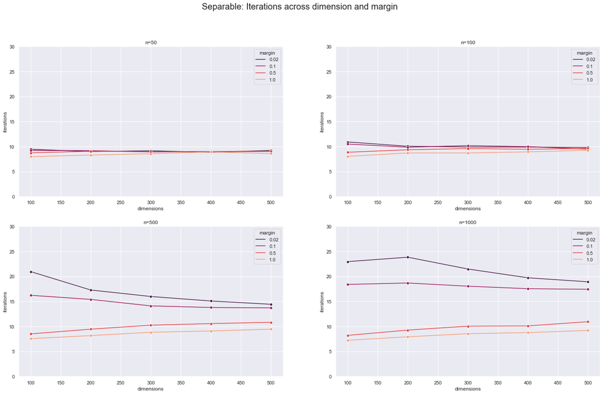

```python
fig1, ax1 = plt.subplots(2, 2, figsize=(24,14))
figure(figsize=(8, 6), dpi=80)
palette = sns.color_palette('rocket', 4)

fig1.suptitle('Separable: Iterations across dimension and margin',size=20)
ax1[0,0].set_title(label = 'n=50')
ax1[0,1].set_title(label = 'n=100')
ax1[1,0].set_title(label = 'n=500')
ax1[1,1].set_title(label = 'n=1000')
p1 = sns.lineplot(data=results_sep[results_sep.sample_size==50], ax=ax1[0,0], y='iterations', x='dimension', hue='margin', palette=palette, marker = 'o');
p2 = sns.lineplot(data=results_sep[results_sep.sample_size==100], ax=ax1[0,1], y='iterations', x='dimension', hue='margin', palette=palette, marker = 'o');
p3 = sns.lineplot(data=results_sep[results_sep.sample_size==500], ax=ax1[1,0], y='iterations', x='dimension', hue='margin', palette=palette, marker = 'o');
p4 = sns.lineplot(data=results_sep[results_sep.sample_size==1000], ax=ax1[1,1], y='iterations', x='dimension', hue='margin', palette=palette, marker = 'o');
p1.set_xlabel("dimensions")
p2.set_xlabel("dimensions")
p3.set_xlabel("dimensions")
p4.set_xlabel("dimensions")
p1.set_ylim(0,30)
p2.set_ylim(0,30)
p3.set_ylim(0,30)
p4.set_ylim(0,30);
p1.legend(title='margin',loc='upper right');
p2.legend(title='margin',loc='upper right');
p3.legend(title='margin',loc='upper right');
p4.legend(title='margin',loc='upper right');
```

### Separable case: Duration

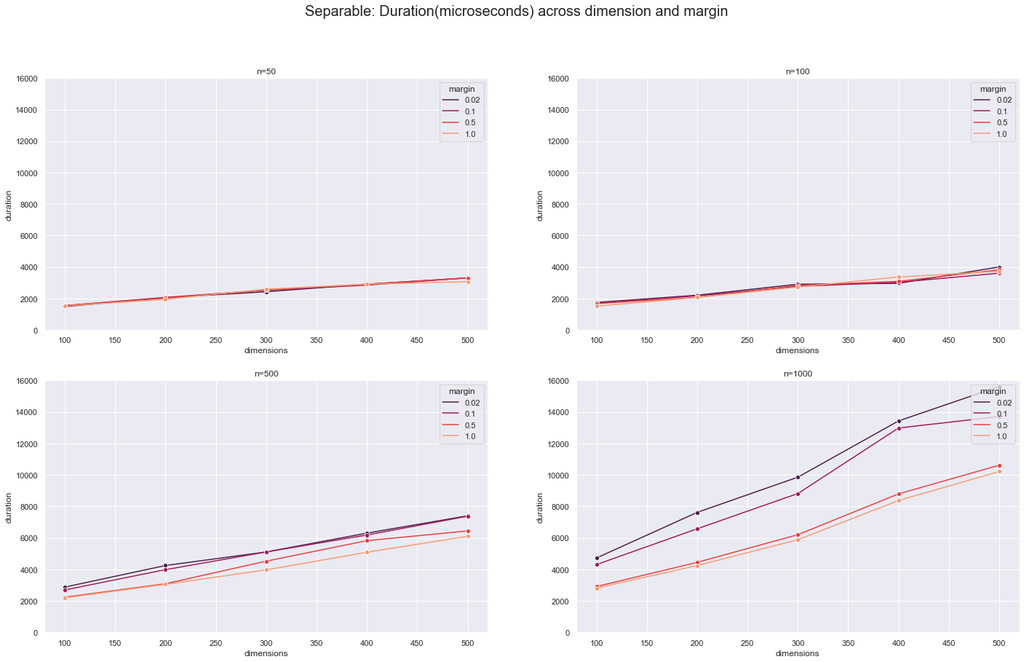

```python
fig1, ax1 = plt.subplots(2, 2, figsize=(24,14))
figure(figsize=(8, 6), dpi=80)
palette = sns.color_palette('rocket', 4)

fig1.suptitle('Separable: Duration(microseconds) across dimension and margin',size=20)
ax1[0,0].set_title(label = 'n=50')
ax1[0,1].set_title(label = 'n=100')
ax1[1,0].set_title(label = 'n=500')
ax1[1,1].set_title(label = 'n=1000')
p1 = sns.lineplot(data=results_sep[results_sep.sample_size==50], ax=ax1[0,0], y='duration', x='dimension', hue='margin', palette=palette, marker = 'o');
p2 = sns.lineplot(data=results_sep[results_sep.sample_size==100], ax=ax1[0,1], y='duration', x='dimension', hue='margin', palette=palette, marker = 'o');
p3 = sns.lineplot(data=results_sep[results_sep.sample_size==500], ax=ax1[1,0], y='duration', x='dimension', hue='margin', palette=palette, marker = 'o');
p4 = sns.lineplot(data=results_sep[results_sep.sample_size==1000], ax=ax1[1,1], y='duration', x='dimension', hue='margin', palette=palette, marker = 'o');
p1.set_xlabel("dimensions")
p2.set_xlabel("dimensions")
p3.set_xlabel("dimensions")
p4.set_xlabel("dimensions")
p1.set_ylim(0,16000)
p2.set_ylim(0,16000)
p3.set_ylim(0,16000)
p4.set_ylim(0,16000);
p1.legend(title='margin',loc='upper right');
p2.legend(title='margin',loc='upper right');
p3.legend(title='margin',loc='upper right');
p4.legend(title='margin',loc='upper right');
```

# Non-separable case

For the non-separable case I will use the following parameters:

dimensions = [2,10,50,100]

sample size = [100,250,500,1000]

margin (mean) = [1,2,3,4]

independent draws = 50

What we can see on this case is the following:

- probability of error is generally in decreasing form as the dimension increases, but with higher dimension sizes the decreasing goes to a significant lower rate. In all cases, there is a clear separation depending on the probability of error depending on the margin, having higher margins (which is influencing the mean of our multivartiate gaussian distribution) makes the probability of error error lower which is what it was expected.
- iterations somewhat stable at around 10 iterations for all sample sizes and margins, but start increasing a bit as dimensionality is increased, more specifically for larger margins, which seems a bit counterintuitive, but could be also a bit noisy as the data seems a bit erratic
- duration behaves similar to the separable case, remains with a very low increasing slope (all dimensionality for all margins) in lower sample sizes but as the sample size increases the slope gets more pronounces as the dimensionality increases

```python
# set parameters
d = [2,10,50,100]
n = [100,250,500,1000]
m = [1,2,3,4]
exps = 50
err_exps = 10
sep = False

l_score = list()
l_duration = list()
l_iterations = list()

l_sample_size = list()
l_dimension = list()
l_margin = list()
l_m = list()

total_iter = len(a)*len(d)*len(n)
iter = 0

# loop through different options for separable case
for sample_size in n:
    for dimension in d:
        for meanm in m:
            # get data
            data, score, duration, iterations, score_err = get_data(sample_size, dimension, -1, 1, margin, exps, err_exps, meanm, sep, tol=1e-3)
            # accumulate lists
            l_score.append(score)
            l_duration.append(duration)
            l_iterations.append(iterations)

            l_sample_size.append(sample_size)
            l_dimension.append(dimension)
            l_m.append(meanm)

            iter += 1
            clear_output(wait=True)
            print(str(iter)+' out of '+str(total_iter))

results_notsep = pd.DataFrame({'sample_size':l_sample_size,'dimension':l_dimension,'m':l_m,'error':l_score,'duration':l_duration,'iterations':l_iterations})
```

```
64 out of 64
```

### Non-Separable case: Probability of error

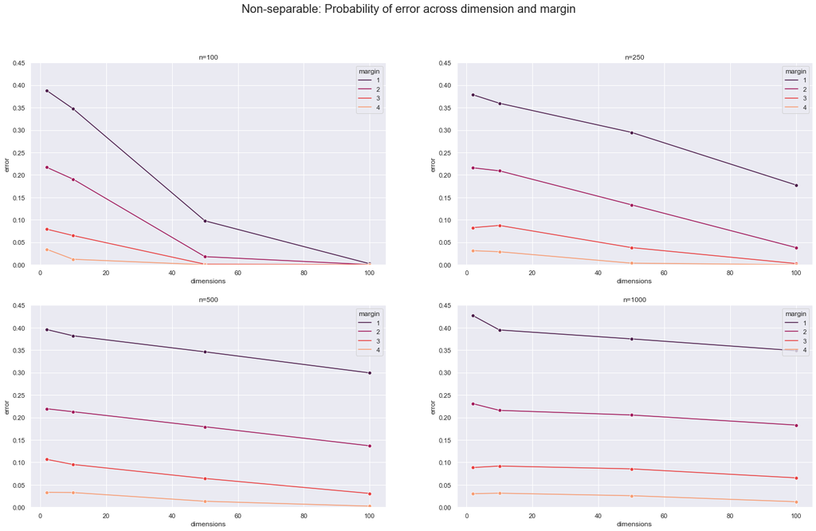

```python
from matplotlib.pyplot import figure
fig1, ax1 = plt.subplots(2, 2, figsize=(24,14))
figure(figsize=(8, 6), dpi=80)
palette = sns.color_palette('rocket', 4)

fig1.suptitle('Non-separable: Probability of error across dimension and margin', size = 20)
ax1[0,0].set_title(label = 'n=100')
ax1[0,1].set_title(label = 'n=250')
ax1[1,0].set_title(label = 'n=500')
ax1[1,1].set_title(label = 'n=1000')
p1 = sns.lineplot(data=results_notsep[results_notsep.sample_size==100], ax=ax1[0,0], y='error', x='dimension', hue='m', palette=palette, marker = 'o');
p2 = sns.lineplot(data=results_notsep[results_notsep.sample_size==250], ax=ax1[0,1], y='error', x='dimension', hue='m', palette=palette, marker = 'o');
p3 = sns.lineplot(data=results_notsep[results_notsep.sample_size==500], ax=ax1[1,0], y='error', x='dimension', hue='m', palette=palette, marker = 'o');
p4 = sns.lineplot(data=results_notsep[results_notsep.sample_size==1000], ax=ax1[1,1], y='error', x='dimension', hue='m', palette=palette, marker = 'o');
p1.set_xlabel("dimensions")
p2.set_xlabel("dimensions")
p3.set_xlabel("dimensions")
p4.set_xlabel("dimensions")
p1.set_ylim(0,0.45)
p2.set_ylim(0,0.45)
p3.set_ylim(0,0.45)
p4.set_ylim(0,0.45);
p1.legend(title='margin',loc='upper right');
p2.legend(title='margin',loc='upper right');
p3.legend(title='margin',loc='upper right');
p4.legend(title='margin',loc='upper right');
```

### Non-Separable case: Iterations

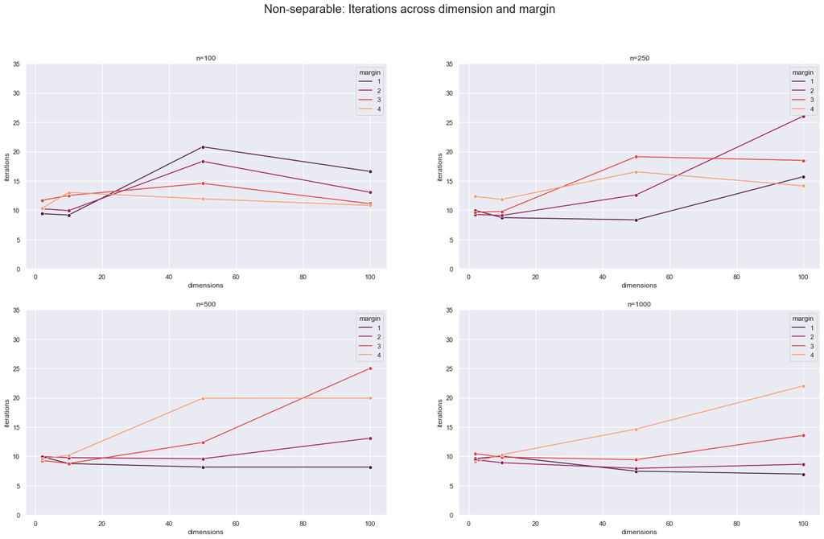

```python
from matplotlib.pyplot import figure
fig1, ax1 = plt.subplots(2, 2, figsize=(24,14))
figure(figsize=(8, 6), dpi=80)
palette = sns.color_palette('rocket', 4)

fig1.suptitle('Non-separable: Iterations across dimension and margin', size = 20)
ax1[0,0].set_title(label = 'n=100')
ax1[0,1].set_title(label = 'n=250')
ax1[1,0].set_title(label = 'n=500')
ax1[1,1].set_title(label = 'n=1000')
p1 = sns.lineplot(data=results_notsep[results_notsep.sample_size==100], ax=ax1[0,0], y='iterations', x='dimension', hue='m', palette=palette, marker = 'o');
p2 = sns.lineplot(data=results_notsep[results_notsep.sample_size==250], ax=ax1[0,1], y='iterations', x='dimension', hue='m', palette=palette, marker = 'o');
p3 = sns.lineplot(data=results_notsep[results_notsep.sample_size==500], ax=ax1[1,0], y='iterations', x='dimension', hue='m', palette=palette, marker = 'o');
p4 = sns.lineplot(data=results_notsep[results_notsep.sample_size==1000], ax=ax1[1,1], y='iterations', x='dimension', hue='m', palette=palette, marker = 'o');
p1.set_xlabel("dimensions")
p2.set_xlabel("dimensions")
p3.set_xlabel("dimensions")
p4.set_xlabel("dimensions")
p1.set_ylim(0,35)
p2.set_ylim(0,35)
p3.set_ylim(0,35)
p4.set_ylim(0,35);
p1.legend(title='margin',loc='upper right');
p2.legend(title='margin',loc='upper right');
p3.legend(title='margin',loc='upper right');
p4.legend(title='margin',loc='upper right');
```

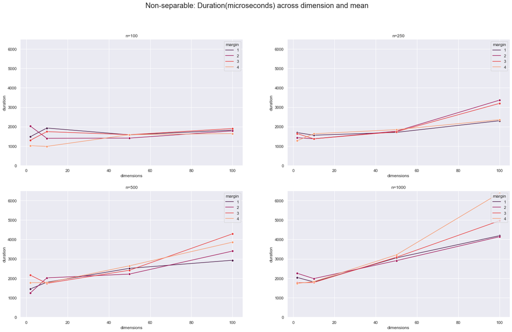

```python
from matplotlib.pyplot import figure
fig1, ax1 = plt.subplots(2, 2, figsize=(24,14))
figure(figsize=(8, 6), dpi=80)
palette = sns.color_palette('rocket', 4)

fig1.suptitle('Non-separable: Duration(microseconds) across dimension and mean', size = 20)
ax1[0,0].set_title(label = 'n=100')
ax1[0,1].set_title(label = 'n=250')
ax1[1,0].set_title(label = 'n=500')
ax1[1,1].set_title(label = 'n=1000')
p1 = sns.lineplot(data=results_notsep[results_notsep.sample_size==100], ax=ax1[0,0], y='duration', x='dimension', hue='m', palette=palette, marker = 'o');
p2 = sns.lineplot(data=results_notsep[results_notsep.sample_size==250], ax=ax1[0,1], y='duration', x='dimension', hue='m', palette=palette, marker = 'o');
p3 = sns.lineplot(data=results_notsep[results_notsep.sample_size==500], ax=ax1[1,0], y='duration', x='dimension', hue='m', palette=palette, marker = 'o');
p4 = sns.lineplot(data=results_notsep[results_notsep.sample_size==1000], ax=ax1[1,1], y='duration', x='dimension', hue='m', palette=palette, marker = 'o');
p1.set_xlabel("dimensions")
p2.set_xlabel("dimensions")
p3.set_xlabel("dimensions")
p4.set_xlabel("dimensions")
p1.set_ylim(0,6500)
p2.set_ylim(0,6500)
p3.set_ylim(0,6500)
p4.set_ylim(0,6500);
p1.legend(title='margin',loc='upper right');
p2.legend(title='margin',loc='upper right');
p3.legend(title='margin',loc='upper right');
p4.legend(title='margin',loc='upper right');
```